# Lab 9 - Multiple Linear Regression

### 6. Model comparison by Akaike Information Criterion

The AIC is a quantitative metric for model “optimization” that balances complexity with model fit. The best models are the ones that fit the data as well as possible, as simply as possible. Recall: lower AIC value indicates a *more optimal* balance - **BUT STATISTICS IS NO SUBSTITUTE FOR JUDGEMENT!!!**

```r
# a. AIC values for each model


sat_aic <- AIC(homes_lm1)
final_aic <- AIC(homes_lm3)

# Answer: which would you pick?
#I would still pick homes_lm3 for the reasons described above
```

### 7. Regression tables with *stargazer*

```r
# a. Prepare a nice regression table:

lm_table <- stargazer(homes_lm1, homes_lm3, type = "html")
```

|  | *Dependent variable:* |  |
| --- | --- | --- |
|  | Price |  |
|  | (1) | (2) |
| CityAtascadero | -9,068.194 | -202,157.500*** |
|  | (29,012.350) | (49,077.010) |
| CitySan Luis Obispo | -76,863.040* | 34,525.410 |
|  | (41,030.470) | (70,837.960) |
| CitySanta Maria-Orcutt | 120,160.700*** | -275,841.300*** |
|  | (28,338.220) | (42,992.760) |
| Bedrooms | -30,792.770*** |  |
|  | (10,841.580) |  |
| Bathrooms | 27,998.670** |  |
|  | (13,251.720) |  |
| SqFt | 230.726*** | 245.934*** |
|  | (14.308) | (15.325) |
| PricePerSqFt | 2,962.850*** |  |
|  | (105.537) |  |
| StatusRegular | -19,792.270 |  |
|  | (29,484.610) |  |
| StatusForeclosure |  | -209,998.900*** |
|  |  | (49,636.970) |
| StatusShort Sale | -41,575.710** | -207,716.400*** |
|  | (18,900.820) | (43,222.290) |
| Constant | -626,690.900*** | 316,332.000*** |
|  | (47,272.690) | (59,022.440) |
| Observations | 403 | 403 |
| R<sup>2</sup> | 0.849 | 0.534 |
| Adjusted R<sup>2</sup> | 0.846 | 0.527 |
| Residual Std. Error | 138,805.900 (df = 393) | 243,102.100 (df = 396) |
| F Statistic | 245.896*** (df = 9; 393) | 75.603*** (df = 6; 396) |
| *Note:* | p<0.1; p<0.05; p<0.01 |  |

```r
# Note: If you want to work with this in Word, save to html, open, copy and paste into Word.
```

### 8. Making predictions

Using your final selected model, predict the housing price for a range of home sizes, sale status, and city.

The predict() function uses the following syntax:

```
  predict(model_name, newdata = new_data_name)
```

Defaults are to exclude the prediction SE and mean confidence interval - if you want to include, use arguments

```
  se.fit = TRUE
  interval = "confidence"
  interval = "prediction"
```

First, you need to create a new data frame of values that contain ALL NECESSARY VARIABLES **with the same variable names AND level strings**.

```r
# First, make a new data frame

# Note that the df_new created below has the SAME variable names and level strings as the original model data (otherwise R won't know how to use it...)
# Work through this on your own to figure out what it actually does:

df_new <- data.frame(City = rep(c("San Luis Obispo",
                                  "Santa Maria-Orcutt",
                                  "Atascadero",
                                  "Arroyo Grande"),
                                each = 60),
                     SqFt = rep(seq(from = 500,
                                    to = 3500,
                                    length = 20),
                                times = 12),
                     Status = rep(c("Regular",
                                    "Foreclosure",
                                    "Short Sale"),
                                  times = 12,
                                  each = 20))
```

Make predictions for the new data using predict():

```r
# a. Make predictions using the new data frame:

price_predict <- predict(homes_lm3, newdata = df_new, se.fit = TRUE, interval = "confidence")
price_predict
```

```
## $fit
##            fit         lwr          upr
## 1    473824.42  332109.954  615538.8884
## 2    512656.12  372315.623  652996.6114
## 3    551487.81  412372.103  690603.5232
## 4    590319.51  452275.423  728363.5950
## 5    629151.21  492021.993  766280.4174
## 6    667982.90  531608.657  804357.1452
## 7    706814.60  571032.748  842596.4457
## 8    745646.29  610292.132  881000.4535
## 9    784477.99  649385.245  919570.7330
## 10   823309.68  688311.119  958308.2500
## 11   862141.38  727069.407  997213.3544
## 12   900973.08  765660.380 1036285.7735
## 13   939804.77  804084.928 1075524.6169
```

[output cut: 895 more lines]

```r
# b. Bind predictions to the data to make it actually useful:

predict_df <- data.frame(df_new, price_predict)
predict_df
```

```
##                   City      SqFt      Status    fit.fit     fit.lwr
## 1      San Luis Obispo  500.0000     Regular  473824.42  332109.954
## 2      San Luis Obispo  657.8947     Regular  512656.12  372315.623
## 3      San Luis Obispo  815.7895     Regular  551487.81  412372.103
## 4      San Luis Obispo  973.6842     Regular  590319.51  452275.423
## 5      San Luis Obispo 1131.5789     Regular  629151.21  492021.993
## 6      San Luis Obispo 1289.4737     Regular  667982.90  531608.657
## 7      San Luis Obispo 1447.3684     Regular  706814.60  571032.748
## 8      San Luis Obispo 1605.2632     Regular  745646.29  610292.132
## 9      San Luis Obispo 1763.1579     Regular  784477.99  649385.245
## 10     San Luis Obispo 1921.0526     Regular  823309.68  688311.119
## 11     San Luis Obispo 2078.9474     Regular  862141.38  727069.407
## 12     San Luis Obispo 2236.8421     Regular  900973.08  765660.380
## 13     San Luis Obispo 2394.7368     Regular  939804.77  804084.928
## 14     San Luis Obispo 2552.6316     Regular  978636.47  842344.544
```

[output cut: 1427 more lines]

Then visualize it!

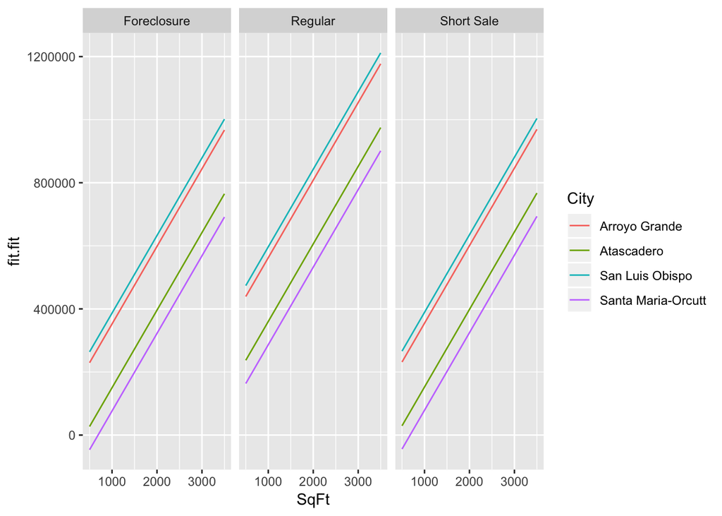

END LAB